# Assignment_FMT_June2020

#### Evaluate regressors on dataset after creating composite feature of water to cement ratio

```python
EvaluateRegressors(df_wc)
```

```
+-------------------+----------------+---------------+-------------------+--------------------+-------------------------+
|     Model Name    | Training Score | Testing Score | Accuracy/R2 score | Mean Squared Error | K Fold Cross Validation |
+-------------------+----------------+---------------+-------------------+--------------------+-------------------------+
|   Decision Tree   |    0.99475     |     0.809     |       0.809       |      56.81467      |         0.87103         |
|   Random Forest   |    0.97364     |    0.87483    |      0.87483      |      37.23507      |         0.90438         |
|    Ada Boosting   |    0.81537     |    0.76284    |      0.76284      |      70.54715      |         0.77405         |
| Gradient Boosting |    0.94157     |    0.86203    |      0.86203      |      41.04248      |         0.89916         |
|      XG Boost     |    0.93836     |    0.86563    |      0.86563      |      39.96993      |         0.89869         |
|    K Neighbors    |    0.85013     |    0.76547    |      0.76547      |      69.76347      |         0.54339         |
|        SVR        |    0.70948     |     0.6724    |       0.6724      |      97.44895      |         0.02979         |
+-------------------+----------------+---------------+-------------------+--------------------+-------------------------+
```

##### Observations:

- Out of all the models (regressors) the following models have performed very well in order of highest to lowest accuracy on dataset after creating composite feature of water to cement ratio
  - Random Forest
  - XG Boost
  - Gradient Boosting
- Other models haven't performed that well with SVR having the lowest score

#### Evaluate regressors on dataset after applying K-Means Clustering

```python
EvaluateRegressors(df_km)
```

```
+-------------------+----------------+---------------+-------------------+--------------------+-------------------------+
|     Model Name    | Training Score | Testing Score | Accuracy/R2 score | Mean Squared Error | K Fold Cross Validation |
+-------------------+----------------+---------------+-------------------+--------------------+-------------------------+
|   Decision Tree   |    0.99475     |     0.7791    |       0.7791      |      65.71107      |         0.86481         |
|   Random Forest   |    0.97398     |    0.88345    |      0.88345      |      34.66975      |         0.89518         |
|    Ada Boosting   |    0.82539     |    0.76919    |      0.76919      |      68.65848      |         0.77863         |
| Gradient Boosting |    0.94493     |    0.86452    |      0.86452      |      40.3002       |          0.902          |
|      XG Boost     |    0.94263     |    0.86417    |      0.86417      |      40.40532      |          0.8998         |
|    K Neighbors    |    0.86642     |    0.78705    |      0.78705      |      63.3443       |         0.68893         |
|        SVR        |     0.7167     |    0.69574    |      0.69574      |      90.50838      |         0.01538         |
+-------------------+----------------+---------------+-------------------+--------------------+-------------------------+
```

##### Observations:

- Out of all the models (regressors) the following models have performed very well in order of highest to lowest accuracy on dataset after applying K-Means Clustering
  - Random Forest
  - Gradient Boosting
  - XG Boost
- Other models haven't performed that well with SVR having the lowest score

### Summary

- Overall the best performing model across all the datasets are Random Forest & Gradient Boosting. Hence, we will perform Feature Importance & Hyper Tuning on these models and find the 95% confidence level.
- Also, we will be working with the K Means Clusterting dataset

### Feature Importance

```
+-------------------+----------------+---------------+-------------------+--------------------+-------------------------+
|     Model Name    | Training Score | Testing Score | Accuracy/R2 score | Mean Squared Error | K Fold Cross Validation |
+-------------------+----------------+---------------+-------------------+--------------------+-------------------------+
|   Random Forest   |    0.97398     |    0.88345    |      0.88345      |      34.66975      |         0.89518         |
| Gradient Boosting |    0.94493     |    0.86452    |      0.86452      |      40.3002       |          0.902          |
+-------------------+----------------+---------------+-------------------+--------------------+-------------------------+
```

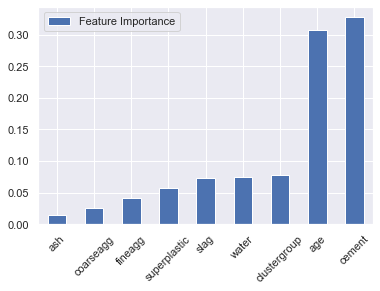

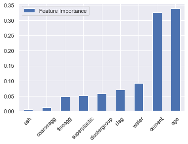

```python
results = SetUpResults()
ModelEvaluation(df_km, 'Random Forest', RandomForestRegressor(random_state = RANDOM_STATE), feature = 1)
ModelEvaluation(df_km, 'Gradient Boosting', GradientBoostingRegressor(random_state = RANDOM_STATE), feature = 1)
PrintResults(results)
```

##### Observations:

- As we have already inferred earlier
  - Feature cement, age, water, slag & superplastic together are important predictors of concrete strength
  - Feature ash, coarseagg & fineagg are weak predictors of concrete strength
- The above graphs of feature importances for both the models depicts the same inference. Only difference is here we have an added feature of clustergroup after performing K Means Clustering

#### Drop the Less Important feature

```
+-------------------+----------------+---------------+-------------------+--------------------+-------------------------+
|     Model Name    | Training Score | Testing Score | Accuracy/R2 score | Mean Squared Error | K Fold Cross Validation |
+-------------------+----------------+---------------+-------------------+--------------------+-------------------------+
|   Random Forest   |    0.97303     |    0.86227    |      0.86227      |      40.96907      |          0.8979         |
| Gradient Boosting |    0.93366     |    0.85464    |      0.85464      |      43.23824      |         0.89373         |
+-------------------+----------------+---------------+-------------------+--------------------+-------------------------+
```

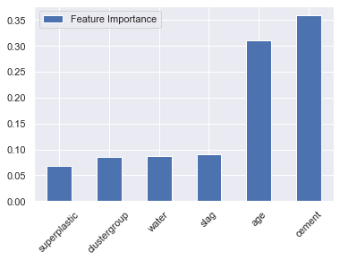

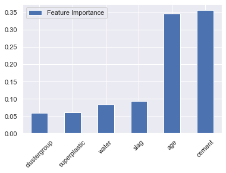

```python
df_imp = df_km.drop(['ash', 'coarseagg', 'fineagg'], axis=1)
results = SetUpResults()
ModelEvaluation(df_imp, 'Random Forest', RandomForestRegressor(random_state = RANDOM_STATE), feature = 1)
ModelEvaluation(df_imp, 'Gradient Boosting', GradientBoostingRegressor(random_state = RANDOM_STATE), feature = 1)
PrintResults(results)
```

### Hyper Tuning

We will hyper tune the models to squeeze out extra performance

#### Hyper Parameter Tuning Function

```python
def RandomForestTuneHyperParams(Xtr, ytr):
    rf = RandomForestRegressor(random_state = RANDOM_STATE)
    est = list(range(50, 300, 50))
    minLeaf = list(range(2, 6))
    minSplit = [2, 3, 4, 5]
    maxDepth = [None, 2, 3, 4, 5]
    criterion = ['mse', 'mae']
    features = ['auto', 'sqrt', 'log2']
    param = dict(criterion = criterion, max_features = features, n_estimators = est,
                 max_depth = maxDepth, min_samples_split = minSplit, min_samples_leaf = minLeaf)
    rs = RandomizedSearchCV(estimator = rf, param_distributions = param, n_jobs = -1)
    rs.fit(Xtr, ytr)

    rf_bestScore = rs.best_score_
    rf_bestParam = rs.best_params_

    #Creating new model with best Parameters and running on the data again
    e = rf_bestParam['n_estimators']
    md = rf_bestParam['max_depth']
    mss = rf_bestParam['min_samples_split']
    msl = rf_bestParam['min_samples_leaf']
    cri = rf_bestParam['criterion']
    f = rf_bestParam['max_features']
    rf = RandomForestRegressor(criterion = cri, max_features = f, n_estimators = e, random_state = RANDOM_STATE,
                                max_depth = md, min_samples_split = mss, min_samples_leaf = msl)
    rf.fit(Xtr, ytr)
    #print("Best Parameter after Hyper Tuning: {0}".format(rf_bestParam))
    return rf

def GradientBoostingTuneHyperParams(Xtr, ytr):
    gb = GradientBoostingRegressor(random_state = RANDOM_STATE)
    est = list(range(50, 300, 50))
    rate = [0.1, 0.2, 0.5]
    minLeaf = list(range(2, 6))
    minSplit = [2, 3, 4, 5]
    maxDepth = [None, 2, 3, 4, 5]
    criterion = ['mse', 'mae', 'friedman_mse']
    loss = ['ls', 'lad', 'huber', 'quantile']
    param = dict(criterion = criterion, loss = loss, n_estimators = est, learning_rate = rate,
                 max_depth = maxDepth, min_samples_split = minSplit, min_samples_leaf = minLeaf)
    gs = RandomizedSearchCV(gb, param, n_jobs = -1)
    gs.fit(Xtr, ytr)

    gb_bestScore = gs.best_score_
    gb_bestParam = gs.best_params_

    #Creating new model with best Parameters and running on the data again
    e = gb_bestParam['n_estimators']
    lr = gb_bestParam['learning_rate']
    md = gb_bestParam['max_depth']
    mss = gb_bestParam['min_samples_split']
    msl = gb_bestParam['min_samples_leaf']
    cri = gb_bestParam['criterion']
    l = gb_bestParam['loss']
    gb = GradientBoostingRegressor(criterion = cri, loss = l, n_estimators = e, learning_rate = lr,
                                    max_depth = md, min_samples_split = mss, min_samples_leaf = msl,
                                  random_state = RANDOM_STATE)
    gb.fit(Xtr, ytr)
    return gb
```

#### Hyper tuned Model Evaluation

```python
results = SetUpResults()
#Hyper tuning both models on dataset with composite feature of water to cement ratio
ModelEvaluation(df_km, 'Random Forest-KM', RandomForestTuneHyperParams, tuning = 1)
ModelEvaluation(df_km, 'Gradient Boosting-KM', GradientBoostingTuneHyperParams, tuning = 1)

#Hyper tuning both models only on the dataset with important feature
ModelEvaluation(df_imp, 'Random Forest-Feat', RandomForestTuneHyperParams, tuning = 1)
ModelEvaluation(df_imp, 'Gradient Boosting-Feat', GradientBoostingTuneHyperParams, tuning = 1)
PrintResults(results)
```

```
+------------------------+----------------+---------------+-------------------+--------------------+-------------------------+
|       Model Name       | Training Score | Testing Score | Accuracy/R2 score | Mean Squared Error | K Fold Cross Validation |
+------------------------+----------------+---------------+-------------------+--------------------+-------------------------+
|    Random Forest-KM    |    0.92461     |    0.84681    |      0.84681      |      45.56807      |         0.87767         |
|  Gradient Boosting-KM  |     0.9765     |    0.86972    |      0.86972      |      38.75537      |         0.92575         |
|   Random Forest-Feat   |    0.93775     |    0.85995    |      0.85995      |      41.66115      |         0.88884         |
| Gradient Boosting-Feat |    0.95667     |    0.86786    |      0.86786      |      39.30813      |         0.91337         |
+------------------------+----------------+---------------+-------------------+--------------------+-------------------------+
```

##### Observations

- After Hyper Tuning the Gradient Boosting Regressor has perfomed well with both K Means clustering dataset & after dropping least significant feature from that dataset.
- Gradient Boosting is a clear winner based on the scores shown after hyper tuning.

### Confidence Level

#### Confidence Level Method

```python
from sklearn.utils import resample
ALPHA = 0.95

# Function to plot the Confidence level
def PlotConfidenceLevel(values):
    plt.hist(values)
    plt.show()
    l, u = ConfidenceLevel(values)
    print('%.1f confidence interval %.1f%% and %.1f%%' % (ALPHA*100, l, u))

# Function to calculate Confidence level
def ConfidenceLevel(score):
    lb = round(((1-ALPHA)/2) * 100, 2)
    ub = round((ALPHA + ((1-ALPHA)/2)) * 100, 2)
    lower = round(max(0, np.percentile(score, lb)) * 100, 2)
    upper = round(min(1, np.percentile(score, ub)) * 100, 2)
    return lower, upper

# Function to Bootstrap model
def BootstrapModel(data, mdl):
    vals = data.values
    # Number of bootstrap samples to create
    n_iter = 1000

    # picking only 50 % of the given data in every bootstrap sample
    n_size = int(len(data) * 0.50)

    # run bootstrap
    stats = list()
    for i in range(n_iter):
        # prepare train and test sets
        # Sampling with replacement
        train = resample(vals, n_samples = n_size)

        # picking rest of the data not considered in sample fit model
        test = np.array([x for x in vals if x.tolist() not in train.tolist()])

        # Splitting the train & test data to Xtrain, ytrain, Xtest, ytest
        Xtr = train[:,:-1]
        ytr = train[:,-1]
        Xtt = test[:,:-1]
        ytt = test[:,-1]

        # Fit Model
        mdl.fit(Xtr, ytr)

        # evaluate model
        predictions = mdl.predict(Xtt)
        score = r2_score(ytt, predictions)
        stats.append(score)

    return stats
```

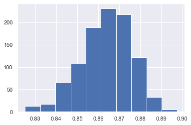

```
95.0 confidence interval 83.7% and 88.4%
```

```python
PlotConfidenceLevel(BootstrapModel(df_km, GradientBoostingRegressor(random_state = RANDOM_STATE)))
```

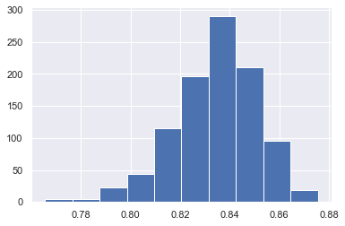

```
95.0 confidence interval 79.6% and 86.2%
```

```python
PlotConfidenceLevel(BootstrapModel(df_km, RandomForestRegressor(random_state = RANDOM_STATE)))
```

### Conclusion

- We performed a detailed EDA of the concrete dataset to for measuring compressive strength.
  - We identified that the data had outliers which were treated by replacing them with their respective median values
  - Also, there was no significant correlation between its attributes
- We created 2 composite features i.e. Water to Cement ratio & Water to Binder ratio after understanding the relevance of each attribute in creating concrete
- We then processed the data with Linear regression model to decide on what model is more helpful. Here, we used PolynomialFeatures to identify whether Quadratic OR Cubic function will help or not. We were able to conclude that both of them were better suited and showcased very good performance then simple linear model.
- We evaluate the mutilpe guassians using K-Means Clusterting and generated 4 separate clusters from the original dataset.
- We considered 7 different Regressors for Model Building on the following datasets we derive in from our analysis
  - Original dataset
  - Dataset with composite feature of Water to Cement ratio
  - Dataset with composite feature of Water to Binder ratio
  - Dataset after performing K-Means clustering
- We shortlisted two models i.e. Random Forest & Gradient Bossting which has overall performed very well amoung all models
- We identify the importance features for both the models & tested the performance after dropping the least significant features
- To squeeze extra performance we performed Hyper tuning on both models & Gradient Boosting model performed really well
- Finally we calculated confidence level by perfoming Bootstrapping of both the models.
  - The 95% confidence interval for Gradient Boosting Regressor is 83.7% and 88.4%
  - The 95% confidence interval for Random Forest Regressor is 79.6% and 86.2%
- Gradient Boosting Regressor would be the best model for this problem after it is hyper tuned.